# Coursera Reproducible Research Assignment

### This report is the result of a Cousera Reproducible Research Assignment to analyse a person’s movement based on data from an activity monitoring device. The dataset used in the report was obtained from https://d396qusza40orc.cloudfront.net/repdata%2Fdata%2Factivity.zip (accessed 13-Feb-2016).The objective of the report is to demonstrate to usefulness of R Markdown in Reproducible research.

### 1. Loading and processing of the data

```r
library(dplyr)
```

```r
library(ggplot2)
# read unzipped csv file and convert date field to date format
activitydata <- read.csv("./activity.csv")
activitydata$date <- as.Date(activitydata$date)
```

### 2. Calculating the total number of steps taken per day.

```r
totals_steps_day <- filter(activitydata, !is.na(steps)) %>%
        group_by(date) %>%
        summarise(total_steps = sum(steps))
totals_steps_day
```

```
## Source: local data frame [53 x 2]
##
##          date total_steps
##        (date)       (int)
## 1  2012-10-02         126
## 2  2012-10-03       11352
## 3  2012-10-04       12116
## 4  2012-10-05       13294
## 5  2012-10-06       15420
## 6  2012-10-07       11015
## 7  2012-10-09       12811
## 8  2012-10-10        9900
## 9  2012-10-11       10304
## 10 2012-10-12       17382
## ..        ...         ...
```

### 3. Histogram of the total number of steps taken each day (excluding missing values)

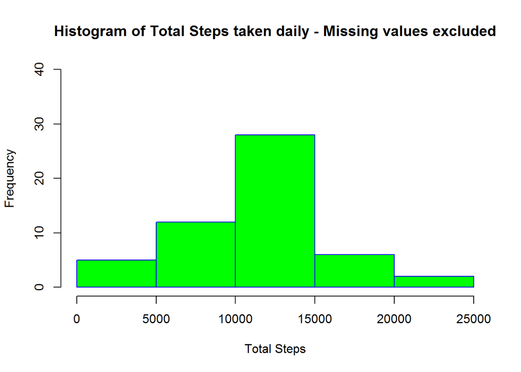

```r
hist(totals_steps_day$total_steps,
    main="Histogram of Total Steps taken daily - Missing values excluded",
    xlab="Total Steps",
    ylim = c(0,40),
    border="blue",
    col="green")
```

### 4. Calculate and report the mean and median of the total number of steps taken per day

```r
mean_median_steps_day <- filter(activitydata, !is.na(steps)) %>%
        group_by(date) %>%
        summarise(mean_steps = mean(steps), median_steps = median(steps))
mean_median_steps_day
```

```
## Source: local data frame [53 x 3]
##
##          date mean_steps median_steps
##        (date)      (dbl)        (dbl)
## 1  2012-10-02    0.43750            0
## 2  2012-10-03   39.41667            0
## 3  2012-10-04   42.06944            0
## 4  2012-10-05   46.15972            0
## 5  2012-10-06   53.54167            0
## 6  2012-10-07   38.24653            0
## 7  2012-10-09   44.48264            0
## 8  2012-10-10   34.37500            0
## 9  2012-10-11   35.77778            0
## 10 2012-10-12   60.35417            0
## ..        ...        ...          ...
```

### 5. Make a time series plot (i.e. type = “l”) of the 5-minute interval (x-axis) the average number of steps taken, averaged across all days (y-axis)

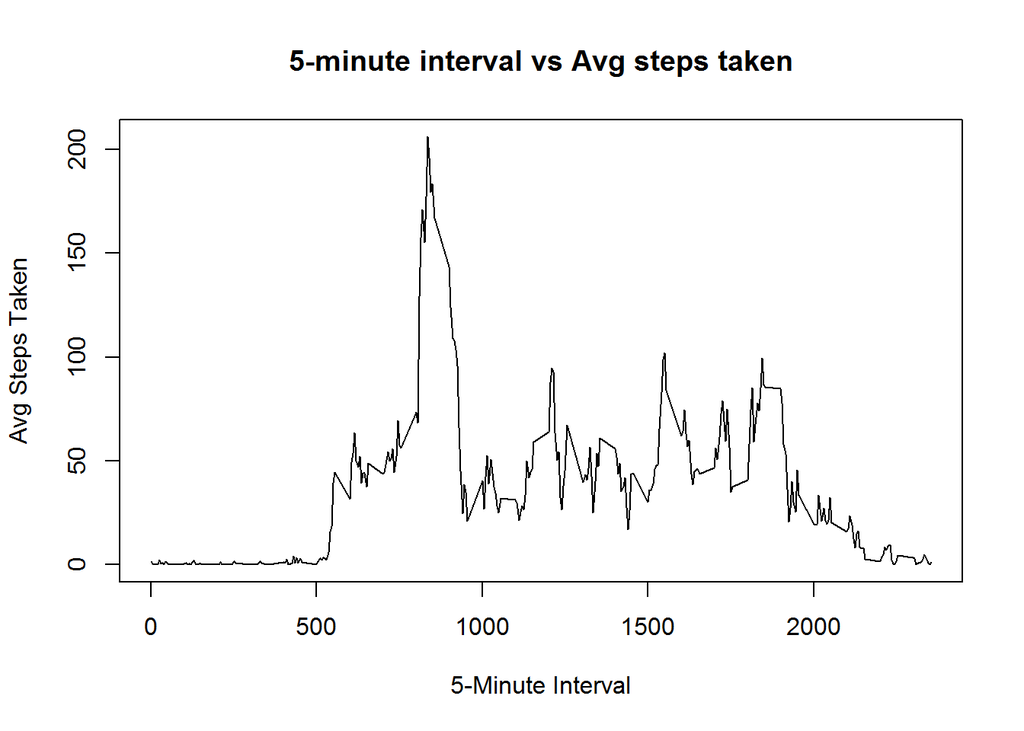

```r
avg_interval_steps <- filter(activitydata, !is.na(steps)) %>%
        group_by(interval) %>%
        summarise(avg_steps = mean(steps))

plot(avg_interval_steps$interval,avg_interval_steps$avg_steps,
    type="l",
    main="5-minute interval vs Avg steps taken",
    xlab="5-Minute Interval",
    ylab="Avg Steps Taken")
```

### 6. Determining the 5-minute interval that, on average, contains the maximum number of steps

```r
max_interval_steps <- filter(avg_interval_steps, avg_steps==max(avg_interval_steps$avg_steps)) %>%
                    select(interval)
max_interval_steps
```

```
## Source: local data frame [1 x 1]
##
##   interval
##      (int)
## 1      835
```

The 5-minute interval with the maximum average number of steps is:

```r
max_interval_steps$interval
```

```
## [1] 835
```

### 7. The strategy used to impute the missing values is as follows: Using a copy of the activitydata data a lookup field is created by combining the day of the week and 5-minute interval number eg.Monday-5, Monday-10, Sunday-100 etc. Using this field another data frame was created with the lookup field and the average number of steps for each day of week-5minute interval combination. The two data frames are then merged by the lookup field and the NA values replaced with this average value. By using this strategy a more accurate estimate of the missing values can be obtained.

#### The total number of missing values in the dataset is:

```r
cnt_na <- NROW(activitydata[is.na(activitydata$steps),])
cnt_na
```

```
## [1] 2304
```

#### Executing the strategy

```r
#Copy data set and add a lookup field
activitydata2 <- activitydata
activitydata2$lookup <- paste(weekdays(activitydata2$date),"-",activitydata2$interval)

#Create data frame with average steps for lookup field
avg_interval_steps_day <- filter(activitydata2, !is.na(steps)) %>%
        group_by(lookup) %>%
        summarise(avg_steps = round(mean(steps),0))

#Merge data sets by lookup field
merged <- merge(activitydata2,avg_interval_steps_day, by.x = "lookup", by.y = "lookup",sort = FALSE)

#Replace missing values with average from lookup field
merged$steps_new <- ifelse(is.na(merged$steps),merged$avg_steps,merged$steps)
```

### 8. Histogram of the total number of steps taken each day after missing values are imputed

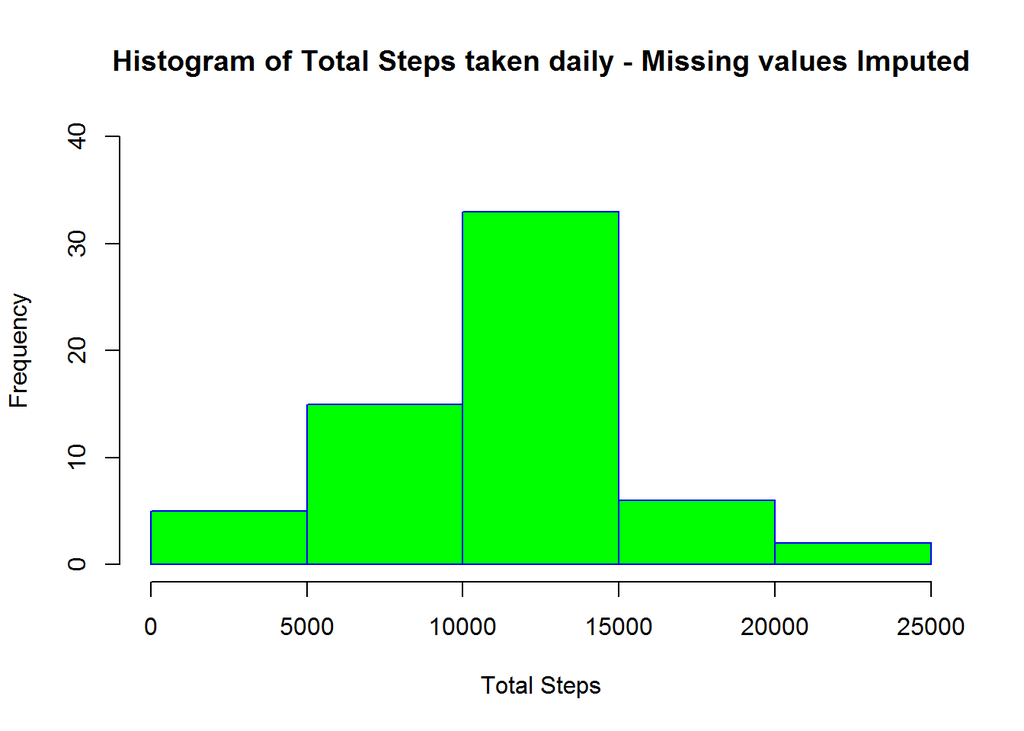

```r
##mean and median total number of steps taken per day.

totals_steps_day2 <- filter(merged, !is.na(steps_new)) %>%
        group_by(date) %>%
        summarise(total_steps = sum(steps_new))

# Histogram of the total number of steps taken each day
hist(totals_steps_day2$total_steps,
    main="Histogram of Total Steps taken daily - Missing values Imputed",
    xlab="Total Steps",
    ylim = c(0,40),
    border="blue",
    col="green")
```

#### Calculating mean and median of total number of steps taken daily

```r
    mean_median_steps_day2 <- filter(merged, !is.na(steps_new)) %>%
        group_by(date) %>%
        summarise(mean_steps = mean(steps_new), median_steps = median(steps_new))
    mean_median_steps_day2
```

```
## Source: local data frame [61 x 3]
##
##          date mean_steps median_steps
##        (date)      (dbl)        (dbl)
## 1  2012-10-01   34.64583            8
## 2  2012-10-02    0.43750            0
## 3  2012-10-03   39.41667            0
## 4  2012-10-04   42.06944            0
## 5  2012-10-05   46.15972            0
## 6  2012-10-06   53.54167            0
## 7  2012-10-07   38.24653            0
## 8  2012-10-08   34.64583            8
## 9  2012-10-09   44.48264            0
## 10 2012-10-10   34.37500            0
## ..        ...        ...          ...
```

### 9. Panel plot comparing the average number of steps taken per 5-minute interval across weekdays and weekends

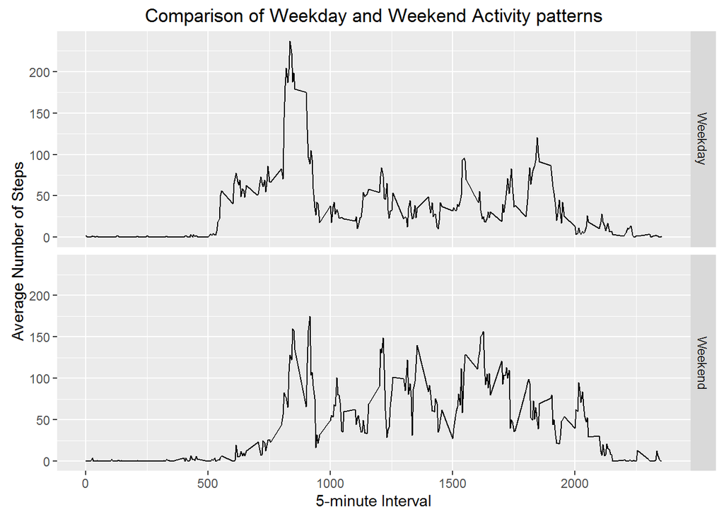

```r
#Insert column to hold day type
merged$day_type <- ifelse(weekdays(merged$date) %in% c("Saturday","Sunday"),"Weekend","Weekday")

#summarise data by day type
day_type_summary <- merged %>% group_by(day_type,interval) %>%
        summarise(avg_steps = mean(steps_new))

#plot chart
qplot(interval,avg_steps,
    data = day_type_summary,
    facets = day_type~. ,
    geom = c("line"),
    xlab = "5-minute Interval",
    ylab = "Average Number of Steps",
    main = "Comparison of Weekday and Weekend Activity patterns")
```